# My Project 1

Gabriela Rodriguez

1 de septiembre de 2017

In this first step we are going to load the data from activity.csv and we are going to clean it, quiting NA’s and transforming date into “date format”

```r
library(readr)
activity <- read_csv("~/Curso Data Science/activity.csv")
d <- na.omit(activity)
d$date <- as.Date(d$date, format("%d/%m/%Y"))
```

## What is mean total number of steps taken per day

First, we are going to calculate the total number of steps taken per day using the function aggregate and make a histogram of the total

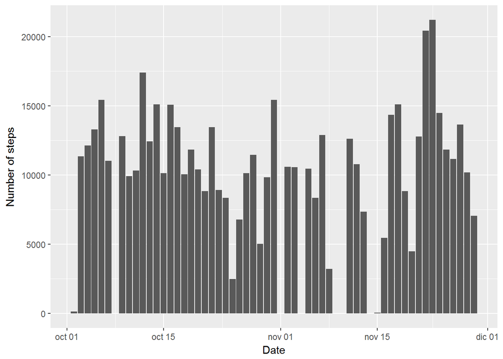

```r
f <- aggregate(d$steps, by=list(d$date), FUN=sum)
f$Group.1 <- as.Date(f$Group.1,  format("%d/%m/%Y"))
library(ggplot2)
total <- ggplot(f, aes(x=Group.1, y=x)) + geom_bar(stat="identity") + labs(x= "Date", y = "Number of steps")
plot(total)
```

[output not shown]

## What is the average daily activity patern

In this question we are going to make a time series plot of the 5 minute interval and the average number of steps taken averaged across all days.

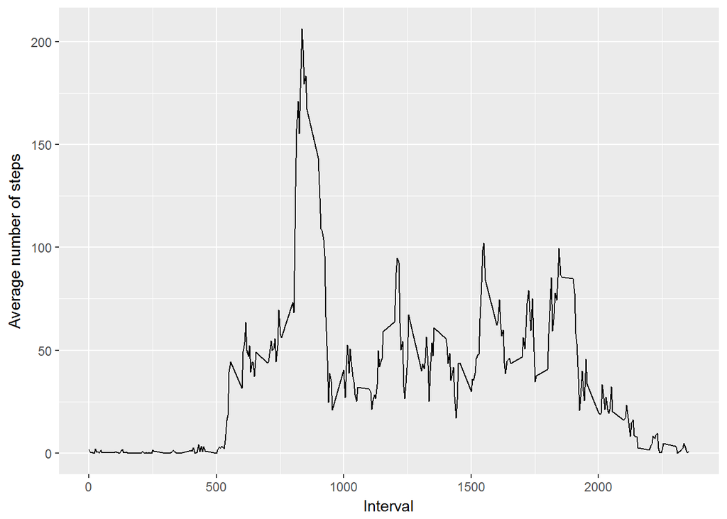

```r
meansperinterval <- aggregate(d$steps, by=list(d$interval), FUN=mean)
p2 <- ggplot(meansperinterval, aes(x=Group.1, y=x)) + geom_line(stat="identity") + labs(x= "Interval", y = "Average number of steps")
plot(p2)
```

Now we are going to calculate which 5 minute interval, on average across all the days contains the maximun number of steps

```r
max <- which.max(meansperinterval[,2])
maxi <- meansperinterval[max,1]
print("The interval with the maximun number of steps is ")
```

```
## [1] "The interval with the maximun number of steps is "
```

```r
maxi
```

```
## [1] 835
```

## Imputing missing values

```r
NAs <- sum(is.na(activity))
print("The number of NA´s is")
```

```
## [1] "The number of NA´s is"
```

```r
NAs
```

```
## [1] 2304
```

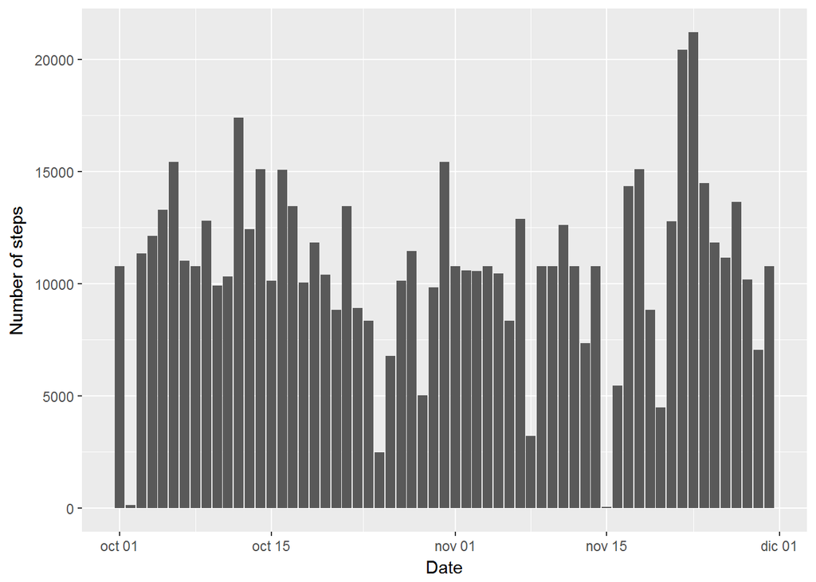

```r
activity[is.na(activity)]  <- mean(d$steps)
f1 <- aggregate(activity$steps, by=list(activity$date), FUN=sum)

f1$Group.1 <- as.Date(f1$Group.1,  format("%d/%m/%Y"))

p3 <- ggplot(f1, aes(x=Group.1, y=x)) + geom_bar(stat="identity") + labs(x= "Date", y = "Number of steps")
plot(p3)
```

In this new dataset we are going to calculate the mean and the median

```r
means2 <- aggregate(activity$steps, by=list(activity$date), FUN=mean)
medians2  <- aggregate(activity$steps, by=list(activity$date), FUN=median)
library(knitr)
kable(means2, caption = "Mean steps per day")
```

Mean steps per day

| Group.1 | x |
| --- | --- |
| 01/10/2012 | 37.3825996 |
| 01/11/2012 | 37.3825996 |
| 02/10/2012 | 0.4375000 |
| 02/11/2012 | 36.8055556 |
| 03/10/2012 | 39.4166667 |
| 03/11/2012 | 36.7048611 |
| 04/10/2012 | 42.0694444 |
| 04/11/2012 | 37.3825996 |
| 05/10/2012 | 46.1597222 |
| 05/11/2012 | 36.2465278 |
| 06/10/2012 | 53.5416667 |
| 06/11/2012 | 28.9375000 |
| 07/10/2012 | 38.2465278 |
| 07/11/2012 | 44.7326389 |
| 08/10/2012 | 37.3825996 |
| 08/11/2012 | 11.1770833 |
| 09/10/2012 | 44.4826389 |
| 09/11/2012 | 37.3825996 |
| 10/10/2012 | 34.3750000 |
| 10/11/2012 | 37.3825996 |
| 11/10/2012 | 35.7777778 |
| 11/11/2012 | 43.7777778 |
| 12/10/2012 | 60.3541667 |
| 12/11/2012 | 37.3784722 |
| 13/10/2012 | 43.1458333 |
| 13/11/2012 | 25.4722222 |
| 14/10/2012 | 52.4236111 |
| 14/11/2012 | 37.3825996 |
| 15/10/2012 | 35.2048611 |
| 15/11/2012 | 0.1423611 |
| 16/10/2012 | 52.3750000 |
| 16/11/2012 | 18.8923611 |
| 17/10/2012 | 46.7083333 |
| 17/11/2012 | 49.7881944 |
| 18/10/2012 | 34.9166667 |
| 18/11/2012 | 52.4652778 |
| 19/10/2012 | 41.0729167 |
| 19/11/2012 | 30.6979167 |
| 20/10/2012 | 36.0937500 |
| 20/11/2012 | 15.5277778 |
| 21/10/2012 | 30.6284722 |
| 21/11/2012 | 44.3993056 |
| 22/10/2012 | 46.7361111 |
| 22/11/2012 | 70.9270833 |
| 23/10/2012 | 30.9652778 |
| 23/11/2012 | 73.5902778 |
| 24/10/2012 | 29.0104167 |
| 24/11/2012 | 50.2708333 |
| 25/10/2012 | 8.6527778 |
| 25/11/2012 | 41.0902778 |
| 26/10/2012 | 23.5347222 |
| 26/11/2012 | 38.7569444 |
| 27/10/2012 | 35.1354167 |
| 27/11/2012 | 47.3819444 |
| 28/10/2012 | 39.7847222 |
| 28/11/2012 | 35.3576389 |
| 29/10/2012 | 17.4236111 |
| 29/11/2012 | 24.4687500 |
| 30/10/2012 | 34.0937500 |
| 30/11/2012 | 37.3825996 |
| 31/10/2012 | 53.5208333 |

```r
kable(medians, caption = "Median steps per day")
```

[output not shown]

Median steps per day

[output not shown]

## Are there differences in activity patterns between weekdays and weekends

This will be done in two parts, in the first one we are going to create a new factor wit two levels “weekday” or “weekend”. Then, we are going to make a plot containing a time series of the 5 minute interval averaged per interval per weekend or weekday

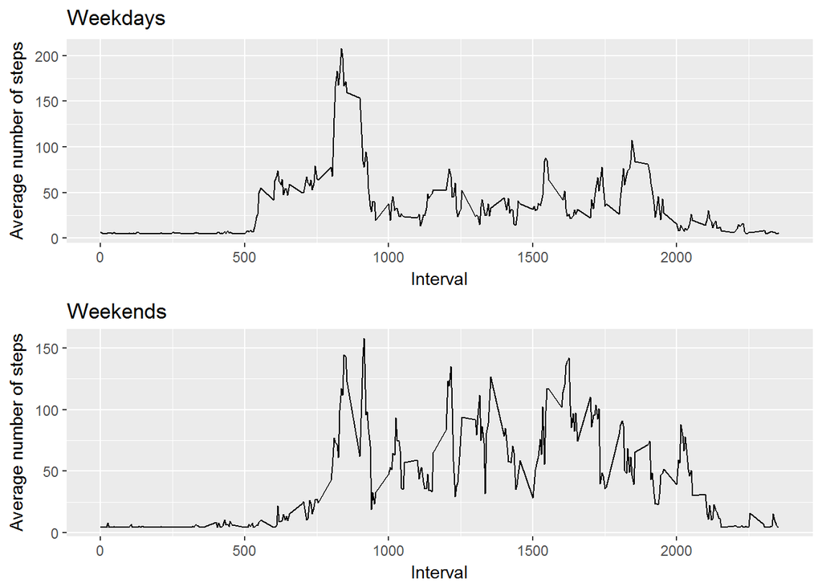

```r
weekdays1 <- c("lunes","lunes","martes","miércoles", "jueves", "viernes")
activity$wday <- c("weekend", "weekday")[(weekdays(as.Date(activity$date, format("%d/%m/%Y") )) %in% weekdays1)+1L]
library(ggplot2)
library(gridExtra)
library(plotly)
d1 <- subset(activity,wday == "weekday")
meansperinterval1 <- aggregate(d1$steps, by=list(d1$interval), FUN=mean)
g1 <- ggplot(meansperinterval1, aes(x=Group.1, y=x)) + geom_line(stat="identity") + labs(x= "Interval", y = "Average number of steps", title = "Weekdays")

d2 <- subset(activity,wday == "weekend")
meansperinterval2 <- aggregate(d2$steps, by=list(d2$interval), FUN=mean)
g2<- ggplot(meansperinterval2, aes(x=Group.1, y=x)) + geom_line(stat="identity") + labs(x= "Interval", y = "Average number of steps", title = "Weekends") + ggtitle("Weekends")
p4 <- grid.arrange(g1,g2, ncol=1, nrow=2)
```